# 03. Docker

Author: Judit Lozano Gondolbeu

## Dockerización de la applicación

Para dockerizar la applicación Flask creada con nuestro modelo de predicción crearemos un nuevo environment con el mínimo de modulos y librerias necesario para llevar el modelo a producción.

```python
#conda create -n deploy python=3.9
```

Para ver los paquetes instalados:

```python
#conda list
```

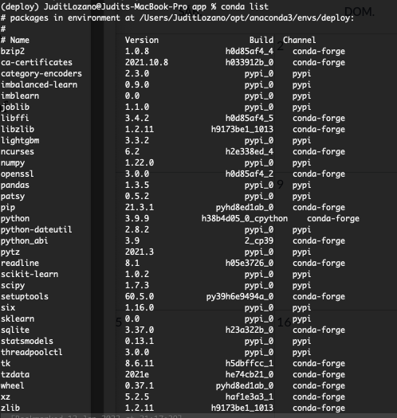

A continuación generaremos un archivo .txt con los paquetes mínimos necesarios para poder instalarlos en el contenedor de docker:

```python
#pip freeze > requirements.txt
```

Después, creamos un archivo sin extension al que se le llama "Dockerfile". A continuación se detallan las instrucciones para que se genere el contenedor de Docker según las dependencias incluidas en archivo requiremnets.txt

[figure not shown]

A continuación, desde el terminal, navegamos al directorio donde tenemos nuestro proyecto y ejecutamos el siguiente comando para generar la imagen de Docker a partir del archivo "Dockerfile" que hemos creado anteriormente.

```python
#docker build -t practica_productivizacion:1.0 .
```

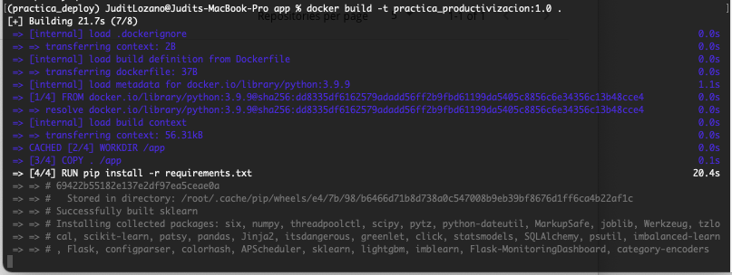

Se observa que la imagen se ha creado correctamente ejecutando en el terminal "docker ps -a":

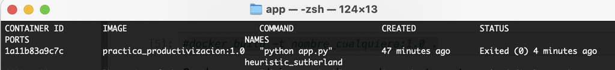

Una vez la imagen de Docker se ha creado, ya se puede ejecutar el contenedor de Docker a partir de la imagen con el siguiente comando:

"docker run -p 5000:80 practica_productivizacion:1.0"

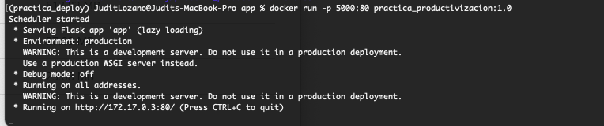

**Atención**

La aplicación de Flask ya está funcionando correctamente dentro del contenedor de docker. Como se muestra en la imagen la aplicación dentro del contenedor de docker está funcionando en http://172.17.0.3:80/ . Sin embargo, este no es el puerto al que tenemos que acceder desde el ordenador para entrar en la aplicación cuando docker está en marcha.

Para acceder a la applicación en este caso, hay que indicar en la barra de navegación: http://localhost:5000 y esto es lo que nos aparece, la pagina principal del modelo llevado a producción a través de una applicación Flask:

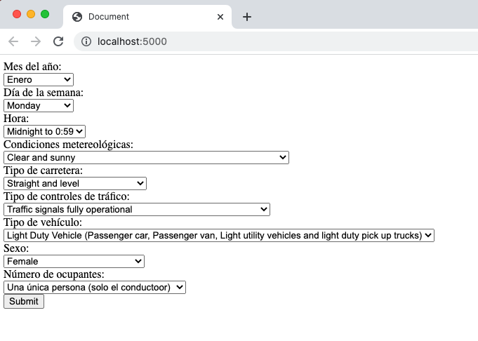

Una vez comprobado que nuestro contenedor docker funciona correctamente, prepararemos una versión para compartir la aplicación.

### Compartir la applicación a través de la imagen de docker

Para compartir la imagen de docker con terceros y que estos puedan reproducir la aplicación en su propio ordenador subiremos la imagen que hemos creado a nuestro repositorio en Docker.

Para ello, generaremos de nuevo una imagen asociada a nuestro nombre de usario a través de un tag:

```python
#docker build -t juditgoes/practica_productivizacion:1.0 .
```

Y por último, haremos push para subir nuestra imagen en remoto:

```python
#docker push juditgoes/practica_productivizacion:1.0
```

A partir de este momento, la imagen de docker "practica_productivizacion:1.0" con nuestro modelo predictivo ya está disponible publicamente para que cualquier usuario la pueda descargar y reproducir en sus ordenadores.

Los pasos para descargar la imagen y ejecutar el contenedor de docker desde cualquier ordenador que tenga docker instalado mediante el terminal:

```python
#docker pull juditgoes/practica_productivizacion:1.0
```

```python
#docker run -p 5000:80 juditgoes/practica_productivizacion:1.0
```

```python
#http://localhost:5000
```

Para ver los contenedores instalados en nuestro ordenador y tomar nota del container ID para su posterior eliminación (si así lo quisieramos):

```python
#docker ps -a
```

Para eliminar el contenedor si ya no nos hace falta a traves del container ID anteriormente señalado (por ejemplo: 1a11b83a9c7c)

```python
# docker rm -f 1a11b83a9c7c
```

### Referencias

https://youtu.be/2X-L9w68898

https://docs.docker.com/